# Prueba final Certificación Profesional en Ciencia de Datos

Fecha de publicación

10 de noviembre de 2025

## Introducción

El Índice de Personal Ocupado (IPO) es un indicador que brinda información sobre la evolución mensual de los obreros ocupados. Es interesante su estudio ya que proporciona datos cruciales sobre la economía y acerca de la estructura del empleo. Además, es considerado un indicador de la “salud” de la economía, ya que en períodos de expansión se espera un aumento de la ocupación, mientras que se espera el efecto contrario en períodos de recesión, donde el desempleo suele ser mayor.

Por ello nos concentramos inicialmente en estudiar la variación del índice. Luego, observaremos si existe algún período con datos atípicos y sus posibles causas. También nos interesa plantear si existe estacionariedad en la ocupación de mano de obra en la industria manufacturera. Y por otro lado, establecer que sector de la misma tiene mayor peso en el índice. Evaluar si todos los sectores se comportan de la misma manera.

Para responder estas preguntas combinaremos métodos de análisis de series temporales y técnicas de machine learning. Para responder las primeras preguntas incluimos: pruebas de raíz unitaria (ADF) para evaluar estacionariedad y modelos ARIMA, FAC y FACP para estudiar la estacionalidad.

El análisis de series temporales permite captar la dinámica temporal, las tendencias y los efectos estacionales, fundamentales para interpretar la evolución mensual de los obreros ocupados por la industria manufacturera.

Por su parte, la cuarta pregunta será abordada mediante el uso de técnicas de machine learning, Random Forest para determinar la importancia relativa de los distintos sectores económicos sobre el empleo total. Además, se complementa el análisis con la matriz de correlaciones entre sectores, con el fin de examinar las interdependencias estructurales del mercado laboral.

El uso de Random Forest resulta apropiado para explorar la importancia de múltiples variables explicativas sin asumir relaciones lineales, brindando además interpretabilidad y robustez frente a colinealidades.

Finalmente, la matriz de correlaciones complementa ambos enfoques al ofrecer una visión descriptiva de las relaciones entre sectores, útil para contextualizar los resultados del modelo predictivo.

## Datos

**Datos Utilizados**

El conjunto de datos fue obtenido directamente del sitio web oficial del INE, en formato .xlsx. El período analizado abarca desde enero de 2018 hasta marzo de 2024, lo que permite estudiar una evolución de más de seis años. Este intervalo se considera suficiente para evaluar tendencias, patrones estacionales y la presencia de posibles datos atípicos, como la pandemia del COVID-19.

El archivo contiene observaciones mensuales, en las que cada fila representa un mes y cada columna corresponde al valor del índice de personal ocupado para cada sector distinto de la industria manufacturera.

¿Que significa cada variable de la base de datos?

| División | Descripción | Tipo |
| --- | --- | --- |
| 10 | Elaboración de productos alimenticios | Cuantitativa |
| 11 | Elaboración de bebidas | Cuantitativa |
| 12 | Elaboración de productos de tabaco | Cuantitativa |
| 13 | Fabricación de productos textiles | Cuantitativa |
| 14 | Fabricación de prendas de vestir | Cuantitativa |
| 15 | Fabricación de cueros y productos conexos | Cuantitativa |
| 16 | Prod. de madera y fab. de productos de madera excepto muebles | Cuantitativa |
| 17 | Fabricación de papel y de los productos de papel | Cuantitativa |
| 18 | Actividades de impresión y reproducción de grabaciones | Cuantitativa |
| 19 | Fabricación de coque y de productos de la refinación del petróleo | Cuantitativa |
| 20 | Fabricación de sustancias y productos químicos | Cuantitativa |
| 21 | Fabricación de productos farmacéuticos | Cuantitativa |
| 22 | Fabricación de productos de caucho y plástico | Cuantitativa |
| 23 | Fabricación de otros productos minerales no metálicos | Cuantitativa |
| 24 | Fabricación de metales comunes | Cuantitativa |
| 25 | Fabricación de productos derivados del metal, excepto maquinaria y equipo | Cuantitativa |
| 26 | Fabricación de los productos informáticos, electrónicos y ópticos | Cuantitativa |
| 27 | Fabricación de equipo eléctrico | Cuantitativa |
| 28 | Fabricación de la maquinaria y equipo n.c.p. | Cuantitativa |
| 29 | Fabricación de vehículos automotores, remolques y semiremolques | Cuantitativa |
| 30 | Fabricación de otros tipos de equipo de transporte | Cuantitativa |
| 31 | Fabricación de muebles | Cuantitativa |
| 32 | Otras industrias manufactureras | Cuantitativa |
| 33 | Reparación e instalación de la maquinaria y equipo | Cuantitativa |

**Transformación de variables**

Inicialmente se realizó la limpieza y preparación de los datos. Se creó un nuevo data frame conservando únicamente las filas 7 a 81, dado que las primeras seis correspondían a encabezados o información no numérica. Posteriormente se seleccionó la cuarta columna, que representa el total de la industria manufacturera.

Dado que los valores se encontraban en formato carácter, se convirtieron a numérico para permitir su tratamiento en los modelos estadísticos. Luego, se aplicó una transformación logarítmica con el objetivo de estabilizar la varianza y facilitar la modelización de la serie. Con estos datos se construyó una serie temporal mensual que abarca desde enero de 2018 hasta marzo de 2024, con frecuencia 12 (mensual).

Para el análisis de posibles valores atípicos, la serie se transformó nuevamente a su nivel original mediante la función exponencial y luego se diferenció, lo que permitió identificar con mayor sensibilidad los datos atípicos, como la caída abrupta observada durante 2020.

Asimismo, se realizo el test de Dickey-Fuller Aumentado (ADF), con el fin de evaluar la estacionariedad de la serie, diferenciamos y confirmamos que el proceso es integrado de orden uno I(1).

Finalmente, para analizar la importancia relativa de los distintos sectores industriales sobre el índice total, se incorporaron las columnas restantes del conjunto de datos, más allá del agregado manufacturero, permitiendo estimar su contribución mediante el uso del Random Forest.

## Análisis y Resultados

### ¿Cómo varía el índice de personal ocupado?

Para comenzar el análisis, se gráfico la evolución mensual del Índice de Personal Ocupado (IPO) en la industria manufacturera entre enero de 2018 y marzo de 2024.

**Ver código**

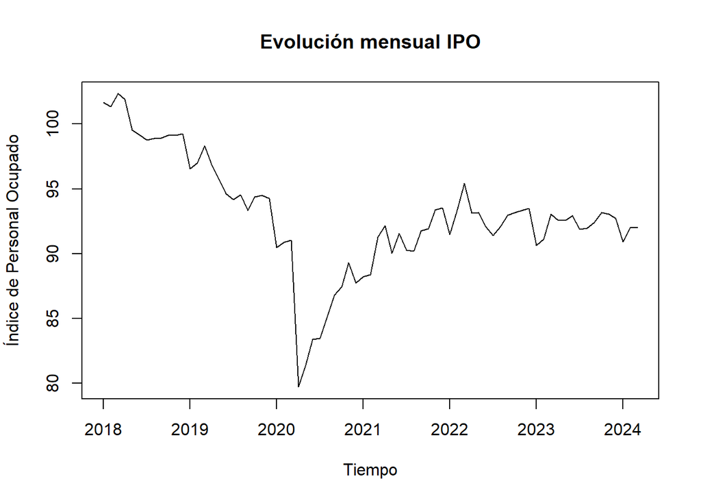

```r
plot(ts_IPO, main = "Evolución mensual IPO", ylab = "Índice de Personal Ocupado", xlab = "Tiempo")
```

En el gráfico se observa una tendencia descendente entre 2018 y 2020, con una caída abrupta en el primer semestre de 2020, atribuible al impacto de la pandemia de COVID-19, que afectó significativamente la producción y el empleo industrial.

Aproximadamente a partir de mediados de 2020 , comienza un proceso de recuperación acelerada, que se estabiliza durante 2021, aunque sin alcanzar los niveles de ocupación previos a la pandemia. Entre 2022y 2024, el índice muestra variaciones moderadas.

Visualmente, la serie presenta comportamientos estacionales sutiles, con picos y caídas recurrentes a fines de cada año, lo que sugiere la existencia de patrones cíclicos propios de la dinámica productiva del sector manufacturero.

Este análisis preliminar permite concluir que el IPO experimentó un deterioro marcado durante la crisis sanitaria, seguido por una recuperación parcial y una posterior estabilización, reflejando tanto los efectos del ciclo económico como las dinámicas estacionales del empleo industrial.

### ¿Se observa algún dato atípico en el empleo en los últimos años? En caso de respuesta afirmativa, ¿A qué se puede deber?

**Ver código**

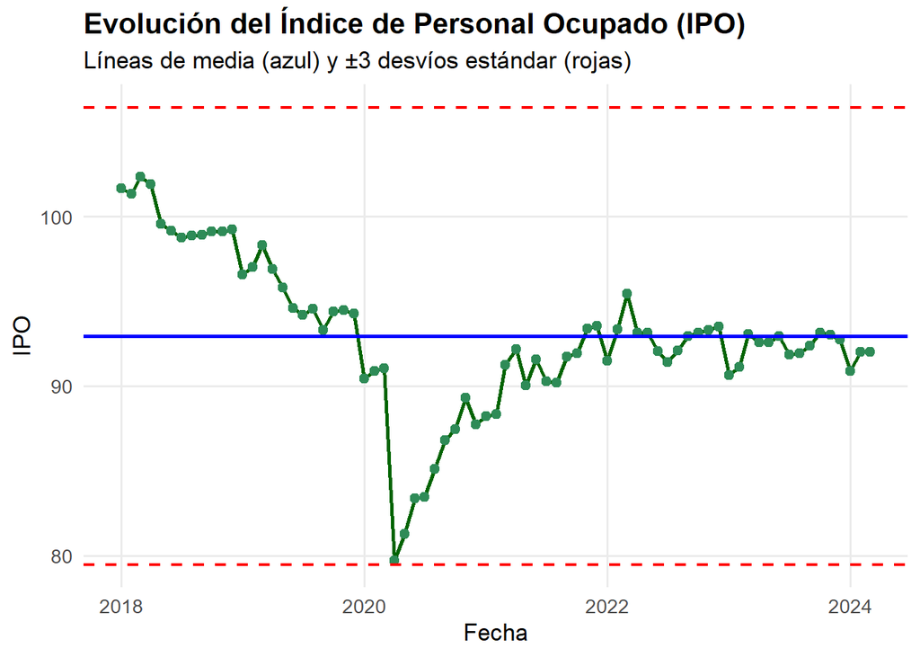

```r
# Calcular media y desvío estándar

media <- mean(datosipo$...4)
desvio <- sd(datosipo$...4)

# Gráfico con ±3 desvíos estándar
ggplot(datosipo, aes(x = fechas, y = ...4)) +
  geom_line(color = "darkgreen", linewidth = 0.9) +
  geom_point(color = "seagreen4", size = 2) +
  geom_hline(yintercept = media, color = "blue", linetype = "solid", linewidth = 1) +
  geom_hline(yintercept = media + 3 * desvio, color = "red", linetype = "dashed", linewidth = 0.8) +
  geom_hline(yintercept = media - 3 * desvio, color = "red", linetype = "dashed", linewidth = 0.8) +
  labs(
    title = "Evolución del Índice de Personal Ocupado (IPO)",
    subtitle = "Líneas de media (azul) y ±3 desvíos estándar (rojas)",
    x = "Fecha",
    y = "IPO"
  ) +
  theme_minimal(base_size = 13) +
  theme(
    plot.title = element_text(face = "bold"),
    panel.grid.minor = element_blank()
  )
```

**Ver código**

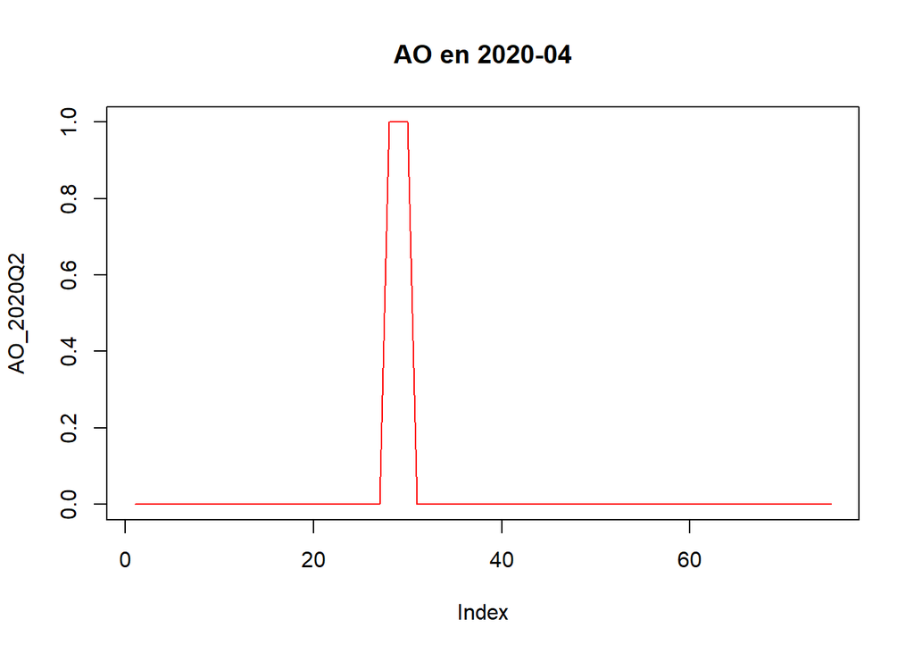

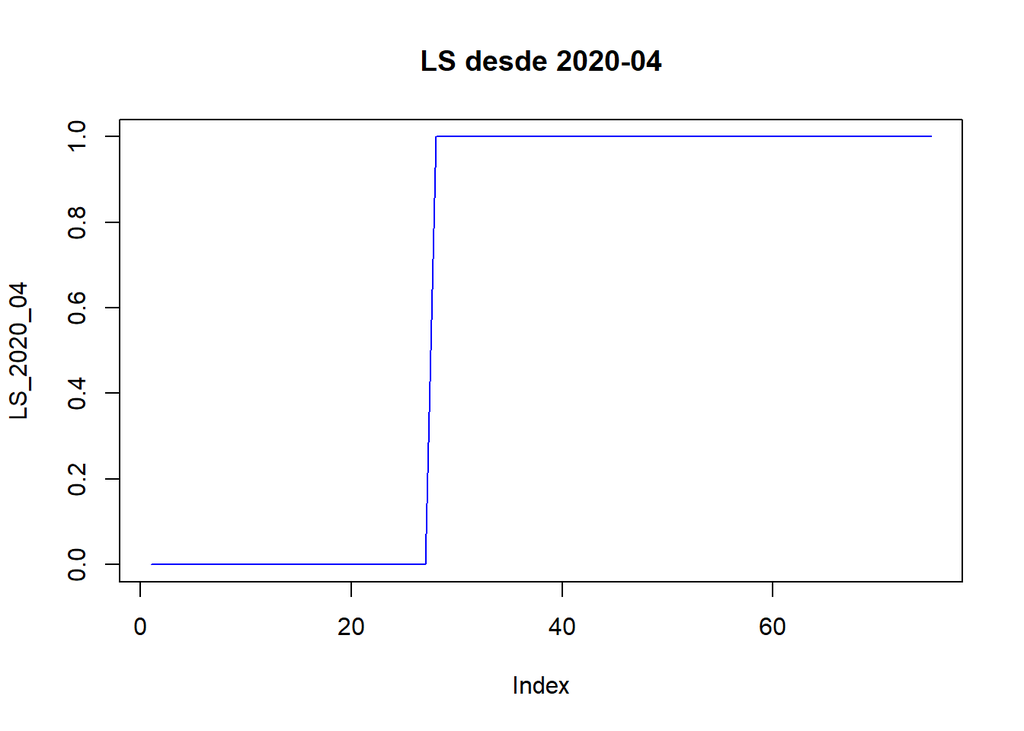

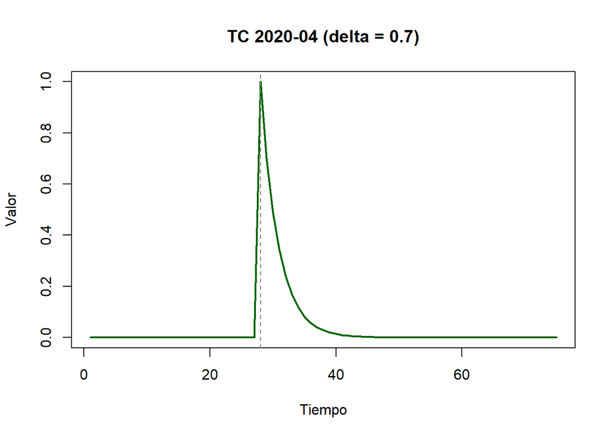

```r
# 2020q2 Probamos diferentes outliers AO, TC, LS
#Excluimos la columna 4 (total industria manufacturera)
vals <- baseipo |>
  dplyr::slice(7:81) |>
  dplyr::pull(4)

#Si vino como list-column, aplanamos
if (is.list(vals)) vals <- unlist(vals, use.names = FALSE)

# Convertir a numérico soportando coma decimal y separador de miles
IPO <- parse_number(as.character(vals),
                    locale = locale(decimal_mark = ",", grouping_mark = "."))

# Armar el data.frame final con el log
datosipo <- tibble(
  fechas = fechas,
  IPO = IPO
) |>
  dplyr::mutate(log_IPO = log(IPO))

# Creo una función auxiliar para ubicar posiciones por año-mes

idx <- function(anio, mes) which(format(fechas, "%Y-%m") == sprintf("%04d-%02d", anio, mes))

#AO: Additive Outlier (pulso puntual). Un “1” solo en el mes del outlier, “0” en el resto.

AO_2020Q2 <- rep(0, n)
AO_2020Q2[idx(2020, 4)] <- 1
AO_2020Q2[idx(2020, 5)] <- 1
AO_2020Q2[idx(2020, 6)] <- 1  #Para marcar todo el trimestre
plot(AO_2020Q2, type="l", main="AO en 2020-04", col="red") #Gráfico del mes 04-2020
#LS: Level Shift (cambio de nivel permanente a partir del shock) Cero antes del shock y uno desde el shock en adelante.

LS_2020_04 <- as.integer(fechas >= as.Date("2020-04-01"))
plot(LS_2020_04, type="l", main="LS desde 2020-04", col="blue")
#TC: Transitory Change (cambio transitorio que decae geométricamente) 1 en el mes del shock y luego decae con razón delta (0<delta<1). Elegí p.ej. delta = 0.7 (podés probar 0.5–0.9).

delta <- 0.7
TC_2020_04 <- rep(0, n)
t0 <- idx(2020, 4)
TC_2020_04[t0:n] <- delta^(0:(n - t0))

#graficamos el cambio transitorio
plot(TC_2020_04, type = "l",
     main = sprintf("TC 2020-04 (delta = %.1f)", delta),
     col = "darkgreen", lwd = 2,
     ylab = "Valor", xlab = "Tiempo")
abline(v = t0, col = "gray50", lty = 2)
```

Una vez planteadas las intervenciones, veremos como varía el modelo según las mismas.

**Ver código**

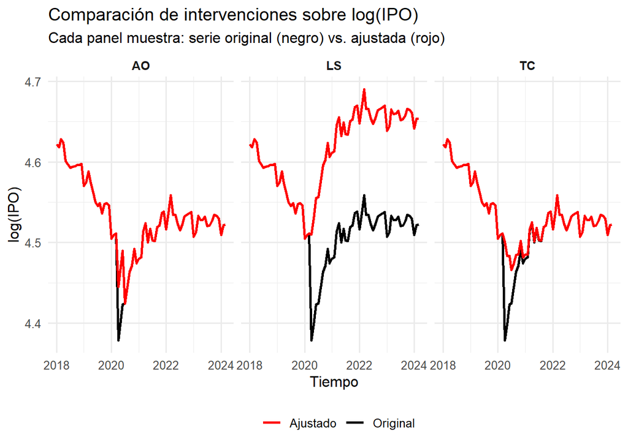

```r
#Unimos los tres graficos para comparar

# Coeficientes de las intervenciones (robusto al nombre)
coef_xreg <- function(fit, k = 1){

   # toma el k-ésimo coef de xreg en el modelo
  idx <- grep("^xreg", names(coef(fit)))
  if (length(idx) < k) stop("No encontré coeficiente xreg #", k, " en el modelo.")
  coef(fit)[idx[k]]
}

b_AO <- as.numeric(coef_xreg(fit_AO, 1))  # si tu AO es un único reg
b_LS <- as.numeric(coef_xreg(fit_LS, 1))
b_TC <- as.numeric(coef_xreg(fit_TC, 1))

#Series ajustadas en LOG(IPO) (resto el efecto estimado del xreg)
ipo_ajust_AO_log <- as.numeric(ts_IPO_log) - b_AO * AO_2020Q2
ipo_ajust_LS_log <- as.numeric(ts_IPO_log) - b_LS * LS_2020_04
ipo_ajust_TC_log <- as.numeric(ts_IPO_log) - b_TC * TC_2020_04

# Data frame largo para comparar en FACETs
df_comp <- tibble(
  Fecha       = as.Date(fechas),
  Original    = as.numeric(ts_IPO_log),
  Ajustado_AO = ipo_ajust_AO_log,
  Ajustado_TC = ipo_ajust_TC_log,
  Ajustado_LS = ipo_ajust_LS_log
) %>%
  # pasamos a largo por modelo (AO/TC/LS)
  pivot_longer(cols = c(Ajustado_AO, Ajustado_TC, Ajustado_LS),
               names_to = "Modelo", values_to = "Ajustado") %>%
  mutate(Modelo = recode(Modelo,
                         "Ajustado_AO" = "AO",
                         "Ajustado_TC" = "TC",
                         "Ajustado_LS" = "LS"))

#Plot: tres paneles alineados, misma escala, original vs ajustado
ggplot(df_comp, aes(x = Fecha)) +
  geom_line(aes(y = Original, color = "Original"), linewidth = 0.9) +
  geom_line(aes(y = Ajustado, color = "Ajustado"), linewidth = 0.9) +
  facet_wrap(~ Modelo, nrow = 1) +
  scale_color_manual(values = c("Original" = "black", "Ajustado" = "red")) +
  labs(title = "Comparación de intervenciones sobre log(IPO)",
       subtitle = "Cada panel muestra: serie original (negro) vs. ajustada (rojo)",
       x = "Tiempo", y = "log(IPO)", color = "") +
  theme_minimal(base_size = 12) +
  theme(legend.position = "bottom",
        strip.text = element_text(face = "bold"))
```

Observando el grafico, podemos concluir que la intervención más eficiente es la AO ya que la misma es la más alineada a la serie original.

### ¿El índice de personal ocupado presenta estacionalidad y estacionariedad?

Utilizando el modelo ajustado por AO, revisamos las funciones de autocorrelación y autocorrelación parcial, esto nos ayuda a observar si hay dependencia temporal o patrón estacional.

**Ver código**

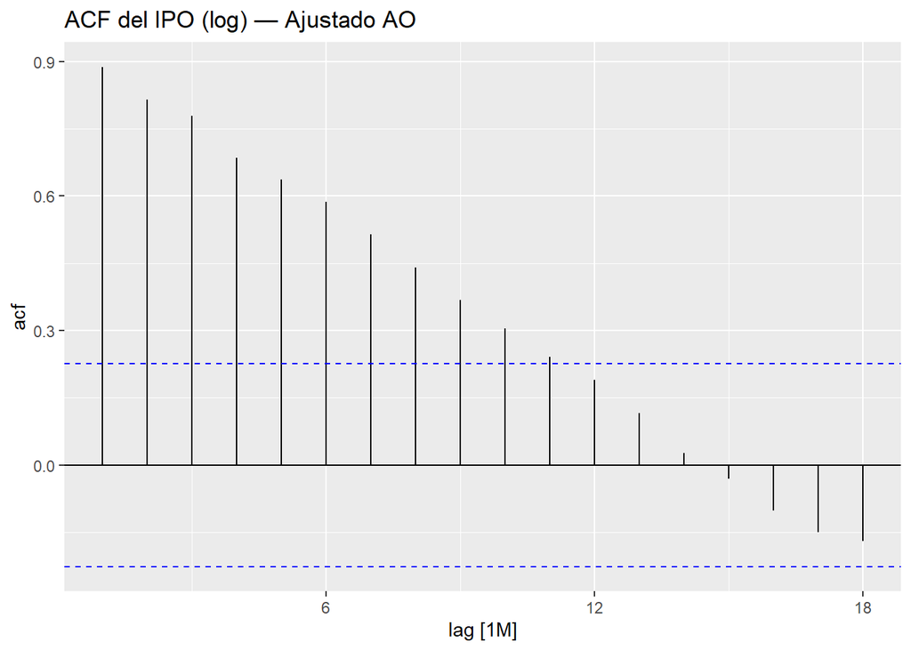

Autocorrelación (ACF): se define como la correlación de una variable consigo misma considerando distintos rezagos del tiempo. ρk = cor(yt, yt−k )

```r
ACF(dts_ajust, y = IPO_log)  |>  autoplot() +
  labs(title = "ACF del IPO (log) — Ajustado AO")
```

**Ver código**

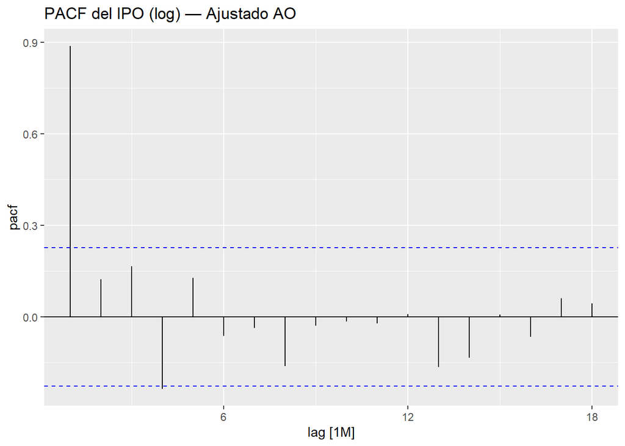

Autocorrelación parcial (PACF): se define la correlación entre yt y yt−k ajustada por el efecto de los rezagos intermedios yt−1, yt−2, . . . , yt−k−1 ρ′k = cor(yt, yt−k |yt−1, . . . , yt−k+1)

```r
PACF(dts_ajust, y = IPO_log) %>% autoplot() +
  labs(title = "PACF del IPO (log) — Ajustado AO")
```

Observación: la correlación entre yt y yt−2 puede ser alta debido a que ambas se relacionan con yt−1. En ese caso la correlación PARCIAL entre yt y yt−2 será nula. ACF y PACF: describen la estructura de dependencia de la serie.

Para saber si la serie es estacionaria aplicamos el test de Dickey-Fuller Aumentado (ADF), el objetivo de esto es contrastar la hipótesis nula de raíz unitaria (no estacionaria).

Test ADF:

**Ver código**

```r
#Test ADF sin constante:
IPODF1 <- ur.df(ts_IPO, type = "none", selectlags = "AIC")
summary(IPODF1)
#Test ADF con constante (drift)
IPODF2 <- ur.df(ts_IPO, type = "drift", selectlags = "AIC")
summary(IPODF2)
```

```
###############################################
# Augmented Dickey-Fuller Test Unit Root Test #
###############################################

Test regression none


Call:
lm(formula = z.diff ~ z.lag.1 - 1 + z.diff.lag)

Residuals:
     Min       1Q   Median       3Q      Max
-11.1476  -0.4719   0.3108   0.9731   3.0684

Coefficients:
            Estimate Std. Error t value Pr(>|t|)
z.lag.1    -0.001766   0.002333  -0.757    0.452
z.diff.lag -0.111916   0.117755  -0.950    0.345

Residual standard error: 1.849 on 71 degrees of freedom
Multiple R-squared:  0.01918,   Adjusted R-squared:  -0.008444
F-statistic: 0.6944 on 2 and 71 DF,  p-value: 0.5027


Value of test-statistic is: -0.757

Critical values for test statistics:
     1pct  5pct 10pct
tau1 -2.6 -1.95 -1.61
```

```
###############################################
# Augmented Dickey-Fuller Test Unit Root Test #
###############################################

Test regression drift


Call:
lm(formula = z.diff ~ z.lag.1 + 1 + z.diff.lag)

Residuals:
     Min       1Q   Median       3Q      Max
-11.3730  -0.5920   0.3020   0.8812   2.5597

Coefficients:
            Estimate Std. Error t value Pr(>|t|)
(Intercept)  9.89647    4.49846   2.200   0.0311 *
z.lag.1     -0.10806    0.04837  -2.234   0.0287 *
z.diff.lag  -0.07427    0.11596  -0.640   0.5240
---
Signif. codes:  0 '***' 0.001 '**' 0.01 '*' 0.05 '.' 0.1 ' ' 1

Residual standard error: 1.801 on 70 degrees of freedom
Multiple R-squared:  0.0782,    Adjusted R-squared:  0.05186
F-statistic: 2.969 on 2 and 70 DF,  p-value: 0.05785


Value of test-statistic is: -2.2341 2.722

Critical values for test statistics:
      1pct  5pct 10pct
tau2 -3.51 -2.89 -2.58
phi1  6.70  4.71  3.86
```

En ambos casos, el tau observado no cae en la región crítica, por lo que no se rechaza la hipótesis nula de raíz unitaria. Basandonos en los graficos FAC y FACP, y en los test ADF, la serie en nivel no es estacionaria, es decir, tiene tendencia o memoria a largo plazo.

Ahora aplicamos el test sobre la serie diferenciada, para ver si la misma es estacionaria.

**Ver código**

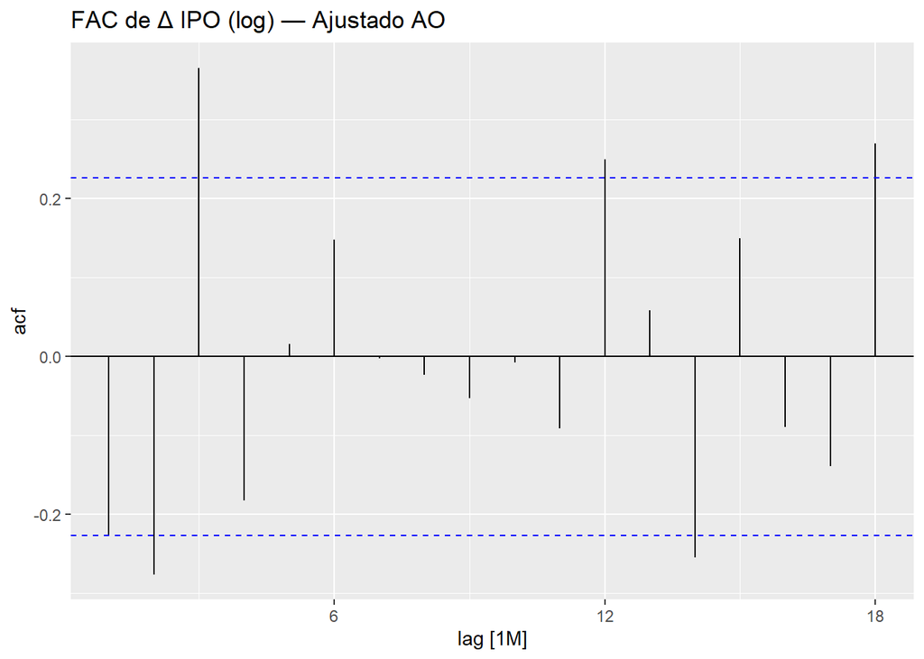

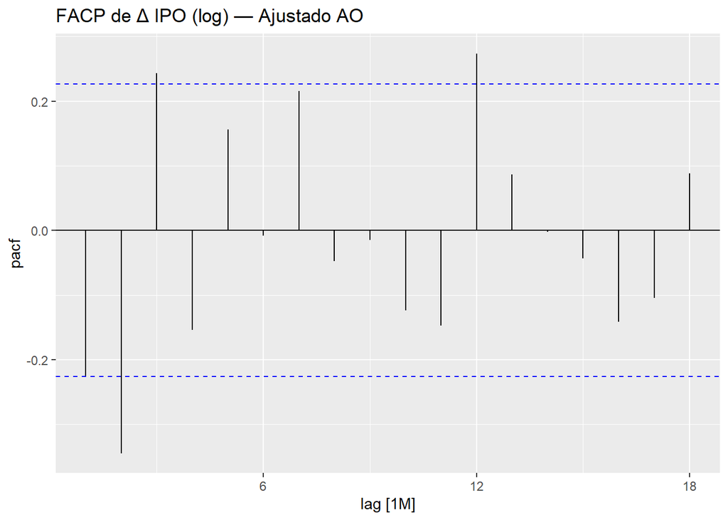

```r
ACF(dts_ajust, y = difference(IPO_log, 1))  %>% autoplot() +
  labs(title = "FAC de Δ IPO (log) — Ajustado AO")
PACF(dts_ajust, y = difference(IPO_log, 1)) %>% autoplot() +
  labs(title = "FACP de Δ IPO (log) — Ajustado AO")
```

**Ver código**

```r
#Test ADF sin constante:
diffIPO <-  diff(ts_IPO)
dIPODF1=ur.df(diffIPO,type="none",selectlags = "AIC")
summary(dIPODF1)
#Test ADF con constante:
dIPODF2=ur.df(diffIPO,type="drift",selectlags = "AIC")
summary(dIPODF2)
```

```
###############################################
# Augmented Dickey-Fuller Test Unit Root Test #
###############################################

Test regression none


Call:
lm(formula = z.diff ~ z.lag.1 - 1 + z.diff.lag)

Residuals:
     Min       1Q   Median       3Q      Max
-11.2289  -0.8296   0.0791   0.6378   3.0057

Coefficients:
           Estimate Std. Error t value Pr(>|t|)
z.lag.1     -1.3131     0.1745  -7.525 1.37e-10 ***
z.diff.lag   0.1883     0.1174   1.603    0.113
---
Signif. codes:  0 '***' 0.001 '**' 0.01 '*' 0.05 '.' 0.1 ' ' 1

Residual standard error: 1.833 on 70 degrees of freedom
Multiple R-squared:  0.5692,    Adjusted R-squared:  0.5569
F-statistic: 46.25 on 2 and 70 DF,  p-value: 1.58e-13


Value of test-statistic is: -7.5249

Critical values for test statistics:
     1pct  5pct 10pct
tau1 -2.6 -1.95 -1.61
```

```
###############################################
# Augmented Dickey-Fuller Test Unit Root Test #
###############################################

Test regression drift


Call:
lm(formula = z.diff ~ z.lag.1 + 1 + z.diff.lag)

Residuals:
     Min       1Q   Median       3Q      Max
-11.0337  -0.6523   0.2601   0.8409   3.2011

Coefficients:
            Estimate Std. Error t value Pr(>|t|)
(Intercept)  -0.1899     0.2177  -0.872   0.3861
z.lag.1      -1.3304     0.1759  -7.563 1.26e-10 ***
z.diff.lag    0.1974     0.1181   1.672   0.0991 .
---
Signif. codes:  0 '***' 0.001 '**' 0.01 '*' 0.05 '.' 0.1 ' ' 1

Residual standard error: 1.836 on 69 degrees of freedom
Multiple R-squared:  0.5739,    Adjusted R-squared:  0.5616
F-statistic: 46.47 on 2 and 69 DF,  p-value: 1.65e-13


Value of test-statistic is: -7.5625 28.5961

Critical values for test statistics:
      1pct  5pct 10pct
tau2 -3.51 -2.89 -2.58
phi1  6.70  4.71  3.86
```

En ambos casos el tau observado cae dentro de la región crítica. Rechazamos la hipótesis nula de raíz unitaria. La serie diferenciada es estacionaria. Por tanto, el IPO es un proceso I(1): no estacionario en nivel, pero estacionario en primera diferencia.

Ahora vamos a analizar la estacionalidad utilizando el modelo ARIMA como método estadístico.

**Ver código**

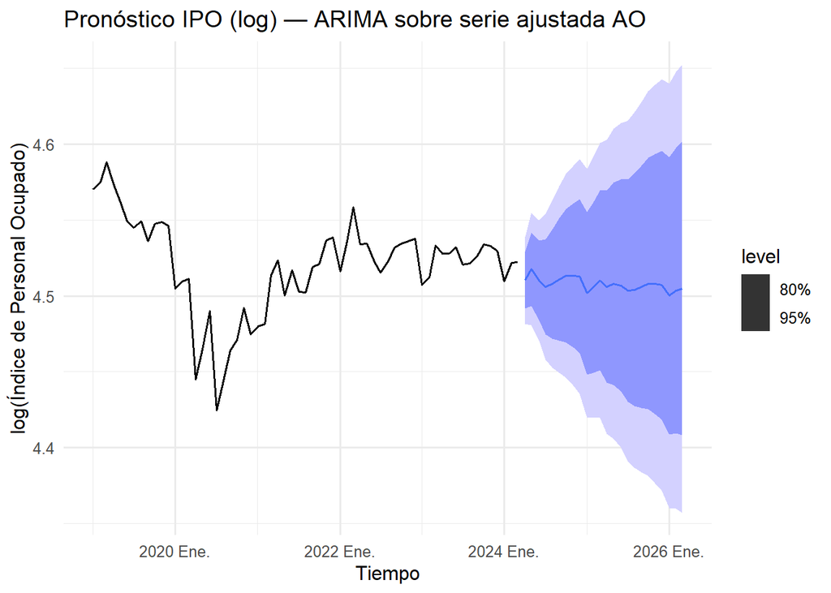

```r
md_fin_AO <- dts_ajust %>% model(ARIMA(IPO_log))

# Predicción a 2 años
fc_AO <- forecast(md_fin_AO, h = "2 years")

# Gráfico de predicción (como en el apunte)
dts_ajust %>%
  filter_index("2019 Jan" ~ .) %>%
  autoplot(IPO_log) +
  autolayer(fc_AO) +
  labs(title = "Pronóstico IPO (log) — ARIMA sobre serie ajustada AO",
       x = "Tiempo", y = "log(Índice de Personal Ocupado)") +
  theme_minimal(base_size = 12)
```

El empleo industrial muestra un comportamiento cíclico y predecible a lo largo del año, con correcciones de corto plazo que se disipan rápidamente.

En términos económicos, el empleo industrial post-pandemia se habría reacondicionado a un régimen estable, en el que las fluctuaciones observadas son principalmente de tipo estacional y transitorio, más que estructural.

### ¿Qué sector tiene más peso en el índice? ¿Todos los sectores se comportan igual?

Con el objetivo de evaluar qué sectores industriales tienen mayor influencia sobre la evolución del Índice Total Industrial, se aplicó un modelo Random Forest, el cual permite estimar la importancia relativa de cada variable sin asumir relaciones lineales.

**Ver código**

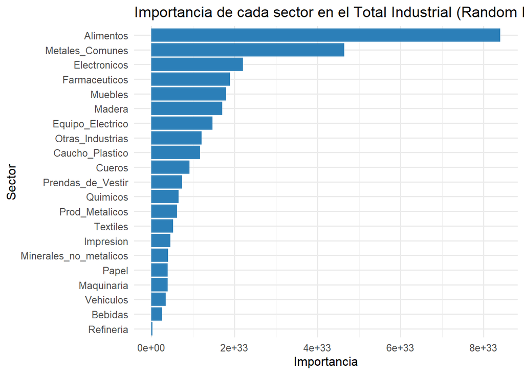

```r
#Primero filtramos los datos relevantes: columnas con sectores

sectores <- baseipo[7:82, 4:27]
colnames(sectores) <- c(  "Total_Industria", "Alimentos", "Bebidas", "Tabaco", "Textiles", "Prendas_de_Vestir", "Cueros",  "Madera", "Papel", "Impresion",  "Refineria", "Quimicos", "Farmaceuticos",  "Caucho_Plastico", "Minerales_no_metalicos", "Metales_Comunes", "Prod_Metalicos", "Electronicos", "Equipo_Electrico",  "Maquinaria", "Vehiculos", "Otros_Transporte",  "Muebles", "Otras_Industrias", "Reparacion_Maquinaria")

#Forzamos TODO a character para evitar choques de tipos

sectores <- sectores %>%
  mutate(across(everything(), ~as.character(.))) %>%
  mutate(across(everything(), ~trimws(.))) %>%            # limpia espacios

#Marcar como NA los símbolos no divulgables / vacíos

mutate(across(everything(), ~na_if(., "(s)"))) %>% mutate(across(everything(), ~na_if(., ""))) %>%

#Convertir a número con coma decimal

    mutate(across(everything(), ~suppressWarnings( parse_number(., locale = locale(decimal_mark = ",", grouping_mark = ".")))))

#Quitar columnas completamente vacías (por ej., Tabaco u Otros transp.)

sectores <- sectores[, colSums(!is.na(sectores)) > 0, drop = FALSE]

#Imputar NAs restantes con promedio de cada columna

sectores <- sectores %>%
  mutate(across(where(is.numeric),
                ~ ifelse(is.na(.), mean(., na.rm = TRUE), .)))

#Calculamos la importancia de los sectores utilizando un modelo Random Forest donde  y = Total_Insutria; x = el resto de sectores

y <- sectores$Total_Industria
X <- sectores %>% select(-Total_Industria)

#Por mayor seguridad quitamos las columnas con varianza 0

var_ok <- sapply(X, function(v) sd(v, na.rm = TRUE) > 0)
X <- X[, var_ok, drop = FALSE]

set.seed(123)
rf_model <- randomForest(
  x = X, y = y, importance = TRUE, ntree = 500)

#Importancia

imp <- as.data.frame(importance(rf_model))
imp$Sector <- rownames(imp)
rownames(imp) <- NULL
if (!"IncNodePurity" %in% names(imp)) {
  # fallback si la columna se llama distinto en tu versión
  names(imp)[1] <- "IncNodePurity"}
imp <- imp %>% arrange(desc(IncNodePurity))

#Gráficamos la importancia por Random Ferost

ggplot(imp, aes(x = reorder(Sector, IncNodePurity), y = IncNodePurity)) +
 geom_col(fill = "#2C7FB8") +
  coord_flip() +
  labs(title = "Importancia de cada sector en el Total Industrial (Random Forest)",
       x = "Sector",
       y = "Importancia") + theme_minimal(base_size = 12)
```

**Ver código**

```r
imp %>%
  arrange(desc(IncNodePurity)) %>%
  gt() %>%
  tab_header(title = md("*Importancia de cada sector en el Total Industrial (Random Forest)*"),
    subtitle = "Medida: IncNodePurity — mayor valor indica")
```

*Importancia de cada sector en el Total Industrial (Random Forest)*

Medida: IncNodePurity — mayor valor indica

| %IncMSE | IncNodePurity | Sector |
| --- | --- | --- |
| 12.7173282 | 8.397680e+33 | Alimentos |
| 8.1444712 | 4.646472e+33 | Metales_Comunes |
| 2.0554466 | 2.202900e+33 | Electronicos |
| 4.3782352 | 1.892842e+33 | Farmaceuticos |
| 3.3400205 | 1.800493e+33 | Muebles |
| 5.1831225 | 1.705880e+33 | Madera |
| 3.5447631 | 1.466739e+33 | Equipo_Electrico |
| 3.8943058 | 1.202574e+33 | Otras_Industrias |
| 2.2936363 | 1.165738e+33 | Caucho_Plastico |
| 2.4363106 | 9.113438e+32 | Cueros |
| 2.8557085 | 7.356828e+32 | Prendas_de_Vestir |
| 2.9682381 | 6.555416e+32 | Quimicos |
| 1.6042133 | 6.187169e+32 | Prod_Metalicos |
| 2.3511436 | 5.199909e+32 | Textiles |
| 1.9559483 | 4.535692e+32 | Impresion |
| -0.7841833 | 3.957349e+32 | Minerales_no_metalicos |
| 0.3704658 | 3.911719e+32 | Papel |
| -0.4673112 | 3.910755e+32 | Maquinaria |
| 1.5204784 | 3.465820e+32 | Vehiculos |
| 0.6932209 | 2.561766e+32 | Bebidas |
| 0.0000000 | 2.202371e+31 | Refineria |

Gracias al modelo Random Forest podemos observar que el sector de alimentos es el que presenta un mayor peso sobre el comportamiento del índice total, seguido por metales comunes y productos electrónicos. En contraste, sectores como bebidas y refinería presentan una importancia mucho menor, lo que sugiere una menor contribución al agregado de la industria manufacturera.

Este resultado es coherente con la estructura productiva del país, en la cual la industria alimenticia concentra una gran parte del empleo y del valor agregado. Los sectores de metales comunes y productos electrónicos también muestran relevancia, probablemente por su vinculación con la demanda exterior y los procesos de inversión industrial.

Ahora observemos que sectores están más correlacionados con el total de la industria.

**Ver código**

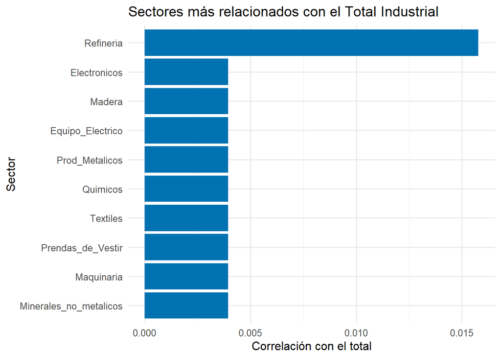

```r
#Buscamos los 10 sectores que se encuentran más correlacionados con el total
corr_mat <- cor(sectores, use = "pairwise.complete.obs")
corr_total <- corr_mat[, "Total_Industria"] %>% sort(decreasing = TRUE)

corr_df <- data.frame(Sector = names(corr_total), Correlacion = corr_total)
#corr_df %>%
  #filter(Sector != "Total_Industria") %>%
  #slice_max(order_by = Correlacion, n = 10)

#Realizamos gráfico de barras de los 10 sectores con mayor correlación

corr_df %>%
  filter(Sector != "Total_Industria") %>%
  arrange(desc(Correlacion)) %>%
  head(10) %>%
  ggplot(aes(x = reorder(Sector, Correlacion), y = Correlacion)) +
  geom_col(fill = "#0072B2") +
  coord_flip() +
  labs(title = "Sectores más relacionados con el Total Industrial",
       x = "Sector", y = "Correlación con el total") +
  theme_minimal(base_size = 12)
```

Para concluir, como ya habiamos observado, el modelo de Random Forest identifica al sector Alimentos como el de mayor peso explicativo sobre el total, seguido por Metales Comunes y Electrónicos, lo que indica que estos sectores son determinantes para comprender las variaciones del índice industrial.

En síntesis, mientras el enfoque de correlaciones permite identificar sectores con comportamientos similares al total, el modelo de Random Forest aporta una visión más profunda sobre cuáles sectores efectivamente explican las fluctuaciones del índice industrial, brindando información más útil para la toma de decisiones y el diseño de políticas industriales.

## Conclusión

Asimismo, el análisis evidenció la presencia de un dato atípico en abril de 2020, asociado al impacto de la pandemia de COVID-19, que generó una interrupción temporal en la tendencia. El uso de un modelo con intervención tipo AO (Additive Outlier) permitió ajustar la serie, manteniendo la coherencia del comportamiento general del índice.

Desde el enfoque de machine learning, el modelo Random Forest reveló que los sectores de Alimentos, Metales comunes y Productos Electrónicos son los que tienen mayor influencia sobre el comportamiento del empleo industrial, mientras que sectores como Bebidas y Refinería presentan una participación menor. Este hallazgo resulta relevante en el contexto económico, ya que permite orientar decisiones de política industrial y de empleo hacia los sectores con mayor capacidad de tracción dentro del mercado laboral manufacturero.

En términos de limitaciones, los resultados se ven condicionados por la cantidad de observaciones disponibles (seis años de datos mensuales), lo que puede restringir la capacidad de detectar cambios estructurales de largo plazo. Además, tanto el modelo ARIMA como el Random Forest presentan limitaciones inherentes: el primero no capta relaciones no lineales o estructurales entre sectores, mientras que el segundo no ofrece interpretaciones causales, sino asociativas. Estas restricciones deben ser consideradas al momento de extrapolar los resultados o utilizarlos para proyecciones futuras.

Finalmente, a modo de proyección, futuros análisis podrían incorporar modelos más avanzados, como VAR o modelos estructurales bayesianos, que permitan capturar relaciones dinámicas entre sectores, o modelos híbridos que combinen técnicas de series temporales con aprendizaje automático (por ejemplo, ARIMA-XGBoost). Asimismo, sería valioso ampliar la base de datos temporal y explorar indicadores complementarios, como el índice de producción física o el salario real, para comprender mejor los factores que determinan el comportamiento del empleo industrial en Uruguay.